# Homework #4: Computational Questions

*All computations should be done in this notebook using the R kernel. Working in small groups is allowed, but it is important that you make an effort to master the material and hand in your own work.*

#### You will be required to submit this notebook, fully compiled with your solutions, as an HTML or ipynb file to Canvas by 2pm on Friday, March 2.

## Problem 1

One really cool (and useful!) application of random variables is approximating integrals/the area under a curve. Consider $f(x) = sin(x)$ on the interval $0 \le x \le \pi$. Let's use uniform random variables to approximate the area under $f(x)$ on this interval. Note that this general idea is used often to solve really important but hard integrals!

#### (a) By hand, and using the ${\tt integrate()}$ function in R, calculate the true area under $f(x)$.

```r
x = function(number) {
    sin(number)
}

area = integrate(x, lower=0, upper=3.141529)
area
```

```
2 with absolute error < 2.2e-14
```

#### (b) Generate $n = 5,000$ uniform random $(x,y)$ coordinates in the rectangle $x \in [0,\pi], \, y \in [0,1]$.

```r
mat = matrix(data=NA, nrow=5000,ncol=2)
mat[,1] = runif(5000, min=0, max=3.141529)
mat[,2] = runif(5000, min=0, max=1)
```

#### (c) Calculate the proportion of points from (b) that fall below $f(x)$ and use this proportion to approximate the area under $f(x)$.

2.0099502542

'This approximate estimation is accurate'

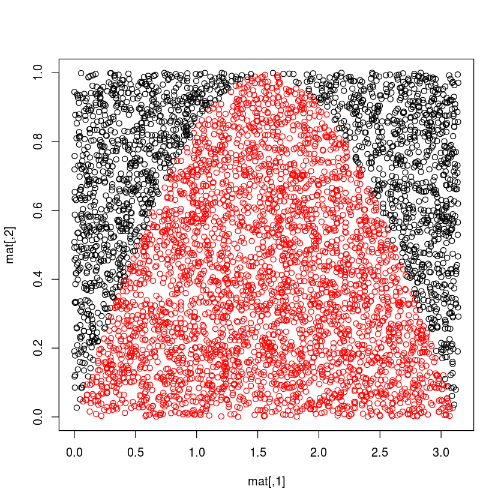

```r
t = seq(0,3.141529,0.1)
y = function(t) sin(t)
z = matrix(data=NA, ncol=2, nrow=5000)
count = 0

for (i in c(1:5000)) {
    if (mat[i,2] < y(mat[i,1])) {
        count = count + 1
    }
}

appx = 3.141529 * (count / 5000)
appx
"This approximate estimation is accurate"

plot(mat, col=ifelse(mat[,2] < y(mat[,1]), "red", "black"))
#lines(t,y(t))
```

#### (d) Find the error between our approximation and the true area calculated in (a). How can we make this error smaller?

```r
diff = appx - 2
diff

"We can make this smaller by increasing the number of data points we have to work with"
```

0.00995025420000006

'We can make this smaller by increasing the number of data points we have to work with'